# Group Project 7– Jayne, Olivia, Sarah

## Data Visualization

Now that we have explored and filtered the data, we should visualize the data before testing our hypotheses.

**(1) Does MYCN amplification have a significant effect on the survival of neuroblastoma patients?**

To visualize how MYCN amplification relates to survival of neuroblastoma patients, we can make a bar plot to compare the two groups using ggplot().

Within ggplot(), you first indicate the data frame you are pulling information from. It then takes the argument aes(x=,y=) where you add your x and y variables and geom_bar() to indicate you want your data to be displayed as a bar graph. We also want to add stat=“identity” so the bar graph gives us counts of Alive vs Dead patients within each group. Within the aes(), we can also add “fill=Vital_Status” so each bar in our graph has a different color to indicate dead vs alive patients.

We can also add ggtitle() to give our plot a title and xlab() and ylab() to label the x and y axes (although we don’t need to relable the x-axis in this case). In addition, we have added the function theme_cowplot() that we can add to all of our plots to give them a consistent and clean theme.

```r
ggplot(data=NBOnly, #Identify the data frame
       aes(x=MYCN,y = Vital_Status, fill=Vital_Status)) + #Identify variables and fill=Vital_Status
  geom_bar(stat = "identity") + #Indicating we want the bar graph to show the vital status counts
  ggtitle("The effect of amplification on survival") + #Title
  ylab("Vital Status") + #Y-axis names
  theme_cowplot()
```

[output not shown]

**The y-axis is weird because of the Unkown bar and idk how to get rid of it/ if we need to get rid of it because we have the key that makes it clear to read**

**(2) Is the length of survival after diagnosis for patients that died significantly different when MYCN is amplified vs. non amplified (Is survival time less with MYCN amplification?)?**

To visualize the relationship between MYCN amplification (a categorical variable) and length of survival (numerical variable), we can create a box plot using the function ggplot(). First we can create a basic boxplot.

```r
basic_plot <- ggplot(NBOnly) + #Tell ggplot what data frame you are working in
  aes(x =MYCN , y=Overall_Survival_Time_in_Days) + #Add x and y variables
  geom_boxplot() #Let ggplot know you want to create a boxplot
basic_plot
```

[output not shown]

```r
DeadOrder<- arrange(dead, Overall_Survival_Time_in_Days)
head(DeadOrder, 25)
```

| Gender | MYCN | Age_Diagnosis | Vital_Status | Diagnostic_Category | Overall_Survival_Time_in_Days | TARGET_USI |
| --- | --- | --- | --- | --- | --- | --- |
| Male | Not Amplified | 31 | Dead | Neuroblastoma | 8 | TARGET-30-PASZKE |
| Female | Amplified | 805 | Dead | Neuroblastoma | 13 | TARGET-30-PADLDT |
| Male | Not Amplified | 4 | Dead | Neuroblastoma | 20 | TARGET-30-PASUML |
| Male | Not Amplified | 663 | Dead | Neuroblastoma | 22 | TARGET-30-PAMVAG |
| Female | Amplified | 890 | Dead | Neuroblastoma | 24 | TARGET-30-PAPHGF |
| Female | Amplified | 611 | Dead | Neuroblastoma | 26 | TARGET-30-PAPGJR |
| Female | Amplified | 605 | Dead | Neuroblastoma | 34 | TARGET-30-PAIEFC |
| Male | Amplified | 860 | Dead | Neuroblastoma | 38 | TARGET-30-PALJPX |
| Female | Not Amplified | 551 | Dead | Neuroblastoma | 61 | TARGET-30-PANEYN |
| Male | Not Amplified | 1643 | Dead | Neuroblastoma | 87 | TARGET-30-PAMLCS |

[output cut: 15 more lines]

```r
tail(DeadOrder, 25)
```

[figure not shown]

| Gender | MYCN | Age_Diagnosis | Vital_Status | Diagnostic_Category | Overall_Survival_Time_in_Days | TARGET_USI |
| --- | --- | --- | --- | --- | --- | --- |
| Female | Not Amplified | 1499 | Dead | Neuroblastoma | 1836 | TARGET-30-PAITRM |
| Male | Not Amplified | 1555 | Dead | Neuroblastoma | 1836 | TARGET-30-PARFWB |
| Female | Not Amplified | 1202 | Dead | Neuroblastoma | 1858 | TARGET-30-PAMRKH |
| Male | Amplified | 656 | Dead | Neuroblastoma | 1912 | TARGET-30-PARJTB |
| Female | Not Amplified | 1031 | Dead | Neuroblastoma | 1933 | TARGET-30-PANUVK |
| Female | Not Amplified | 1319 | Dead | Neuroblastoma | 2002 | TARGET-30-PASCJJ |
| Female | Not Amplified | 3625 | Dead | Neuroblastoma | 2039 | TARGET-30-PARBGP |
| Female | Amplified | 573 | Dead | Neuroblastoma | 2056 | TARGET-30-PAPSEI |
| Male | Not Amplified | 1157 | Dead | Neuroblastoma | 2103 | TARGET-30-PALPKZ |
| Female | Amplified | 720 | Dead | Neuroblastoma | 2195 | TARGET-30-PALTYS |

[output cut: 15 more lines]

Is there a relationship between gender and days of survival?? WILL DECIDE IF WE WILL DELETE OR NOT

```r
table(dead$Gender)
```

```
Female   Male
    99    133
```

```r
alive<- filter(NBOnly, Vital_Status=="Alive")
head(alive)
```

| Gender | MYCN | Age_Diagnosis | Vital_Status | Diagnostic_Category | Overall_Survival_Time_in_Days | TARGET_USI |
| --- | --- | --- | --- | --- | --- | --- |
| Male | Not Amplified | 557 | Alive | Neuroblastoma | 2872 | TARGET-30-PADFLI |
| Male | Not Amplified | 1916 | Alive | Neuroblastoma | 4596 | TARGET-30-PADIHC |
| Female | Not Amplified | 1191 | Alive | Neuroblastoma | 3855 | TARGET-30-PADIRB |
| Male | Not Amplified | 554 | Alive | Neuroblastoma | 2644 | TARGET-30-PADKGF |
| Male | Not Amplified | 1837 | Alive | Neuroblastoma | 4670 | TARGET-30-PADLIC |
| Male | Amplified | 780 | Alive | Neuroblastoma | 1749 | TARGET-30-PADLKJ |

```r
table(alive$Gender)
```

```
Female   Male
    90    141
```

**(4) For patients who died, does patient age at diagnosis correlate with the number of days they survived after diagnosis?**

To get a quick sense of this question, we decided to look at the numerical summary for the distribution of days of survival after diagnosis for patients who died. We saw that the mean was about 930 days. So, we ordered the data from youngest patient diagnosed to oldest patient diagnoses. From there, we looked at the youngest 25 patients diagnosed and the oldest 25 patients diagnosed and saw that for the younger patients, most of the survival times were below the 930 day average, and for the older patients, most had survival times above 930 days. This leads us to a further analysis as to if younger patients have significantly lower life expectancies after a neuroblastoma diagnosis.

```r
summary(dead$Overall_Survival_Time_in_Days)
```

```
   Min. 1st Qu.  Median    Mean 3rd Qu.    Max.
    8.0   416.0   787.0   930.2  1311.8  3691.0
```

```r
dead<-arrange(dead, Age_Diagnosis)
head(dead, 25)
```

| Gender | MYCN | Age_Diagnosis | Vital_Status | Diagnostic_Category | Overall_Survival_Time_in_Days | TARGET_USI |
| --- | --- | --- | --- | --- | --- | --- |
| Male | Not Amplified | 4 | Dead | Neuroblastoma | 20 | TARGET-30-PASUML |
| Male | Not Amplified | 31 | Dead | Neuroblastoma | 8 | TARGET-30-PASZKE |
| Female | Not Amplified | 328 | Dead | Neuroblastoma | 481 | TARGET-30-PATYIL |
| Female | Not Amplified | 341 | Dead | Neuroblastoma | 2466 | TARGET-30-PARHAM |
| Female | Amplified | 406 | Dead | Neuroblastoma | 333 | TARGET-30-PASHFA |
| Female | Amplified | 522 | Dead | Neuroblastoma | 682 | TARGET-30-PASJYB |
| Female | Amplified | 549 | Dead | Neuroblastoma | 703 | TARGET-30-PAIUJB |
| Female | Not Amplified | 551 | Dead | Neuroblastoma | 61 | TARGET-30-PANEYN |
| Female | Amplified | 557 | Dead | Neuroblastoma | 237 | TARGET-30-PAPZWS |
| Male | Amplified | 564 | Dead | Neuroblastoma | 1368 | TARGET-30-PAIXRK |

[output cut: 15 more lines]

```r
tail(dead, 25)
```

| Gender | MYCN | Age_Diagnosis | Vital_Status | Diagnostic_Category | Overall_Survival_Time_in_Days | TARGET_USI |
| --- | --- | --- | --- | --- | --- | --- |
| Male | Amplified | 1942 | Dead | Neuroblastoma | 1116 | TARGET-30-PARDYU |
| Female | Not Amplified | 1955 | Dead | Neuroblastoma | 1102 | TARGET-30-PAPUWY |
| Male | Not Amplified | 1961 | Dead | Neuroblastoma | 1765 | TARGET-30-PAPVFD |
| Female | Not Amplified | 1972 | Dead | Neuroblastoma | 1438 | TARGET-30-PASGPY |
| Male | Not Amplified | 1978 | Dead | Neuroblastoma | 1540 | TARGET-30-PAMVLG |
| Male | Not Amplified | 1996 | Dead | Neuroblastoma | 240 | TARGET-30-PADPCI |
| Male | Amplified | 2008 | Dead | Neuroblastoma | 2636 | TARGET-30-PAPCTS |
| Male | Not Amplified | 2178 | Dead | Neuroblastoma | 724 | TARGET-30-PARURB |
| Male | Not Amplified | 2241 | Dead | Neuroblastoma | 1321 | TARGET-30-PARGKK |
| Female | Not Amplified | 2274 | Dead | Neuroblastoma | 3691 | TARGET-30-PADXAS |

[output cut: 15 more lines]

**(5) Do patients above and below the median age of diagnosis (18 mo) have different survival rates?**

The median age of diagnosis for neuroblastoma is 18 months old (~550 days). We want to explore whether being above or below the median age of diagnosis has a significant effect on survival rate. We have created two subsets of the dataframe including all neuroblastoma patients– one with patients diagnosed earleir than 18 months, and one including patients diagnosed later than 18 months. We used the table function sorted for vital status to see how many patients in each group were alive or dead. We first notice that the TARGET data has more patients diagnosed older than 18 mo which is inconsistent with the literature data and what we would expect from a random sample. This should be noted and flagged for potential sampling biases. Despite this, we see that a higher percentage of patients who are under the 18 mo threshold survive (~92%) compared to a much lower percentage of patients above the 18 mo threshold that survive (~41%).

```r
Less18<-filter(NBOnly, Age_Diagnosis<550)
table(Less18$Vital_Status)
```

```
Alive  Dead
   75     7
```

```r
Greater18<-filter(NBOnly, Age_Diagnosis>=550)
table(Greater18$Vital_Status)
```

```
Alive  Dead
  156   225
```

## Grading

Each student will be expected to complete the following tasks to earn 85% of the points available for this assignment (21/25).

- Identify and obtain suitable dataset
- Use a Github repository and version control to collaborate on the project
- Spend 4-6 hours preparing, coding, and testing tutorial
  - Data exploration
  - Data visualization
  - Hypothesis testing
- Present tutorial in class
- Provide public archive suitable for sharing to students/faculty

Tutorials from previous classes can be viewed at our public github site: https://github.com/Bucknell-Biol364

Each group should use an *Acknowledgements* section to document the participation of each member and the collaboration within and between groups.

Additional credit will be awarded for providing assistance to other groups and for the development of a tutorial that goes beyond the minimal expectations listed above.

## Sample Dataset

One of the possible datasets to use for the tutorial can be found in the datasauRus package.

```r
datasaurus_dozen %>%
  group_by(dataset) %>%
  summarize(
      mean_x    = mean(x),
      mean_y    = mean(y),
      std_dev_x = sd(x),
      std_dev_y = sd(y),
      corr_x_y  = cor(x, y)
      )
```

| dataset | mean_x | mean_y | std_dev_x | std_dev_y | corr_x_y |
| --- | --- | --- | --- | --- | --- |
| away | 54.26610 | 47.83472 | 16.76982 | 26.93974 | -0.06412835 |
| bullseye | 54.26873 | 47.83082 | 16.76924 | 26.93573 | -0.06858639 |
| circle | 54.26732 | 47.83772 | 16.76001 | 26.93004 | -0.06834336 |
| dino | 54.26327 | 47.83225 | 16.76514 | 26.93540 | -0.06447185 |
| dots | 54.26030 | 47.83983 | 16.76774 | 26.93019 | -0.06034144 |
| h_lines | 54.26144 | 47.83025 | 16.76590 | 26.93988 | -0.06171484 |
| high_lines | 54.26881 | 47.83545 | 16.76670 | 26.94000 | -0.06850422 |
| slant_down | 54.26785 | 47.83590 | 16.76676 | 26.93610 | -0.06897974 |
| slant_up | 54.26588 | 47.83150 | 16.76885 | 26.93861 | -0.06860921 |
| star | 54.26734 | 47.83955 | 16.76896 | 26.93027 | -0.06296110 |

[output cut: 3 more lines]

Boxplots of either the x or the y value show that there is something strange going on.

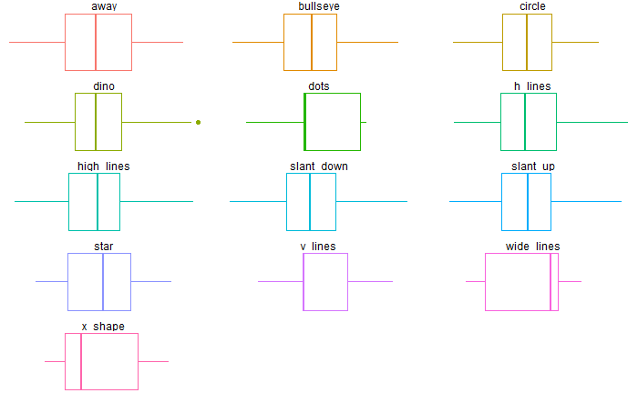

```r
ggplot(datasaurus_dozen, aes(x = x, colour = dataset))+
    geom_boxplot()+
    theme_void()+
    theme(legend.position = "none")+
    facet_wrap(~dataset, ncol = 3)
```

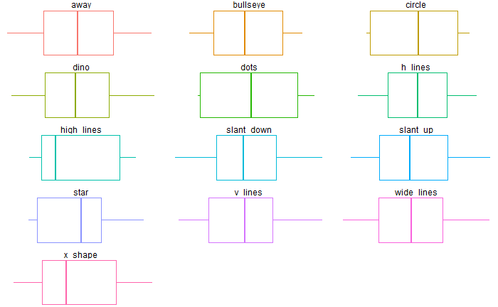

```r
ggplot(datasaurus_dozen, aes(x = y, colour = dataset))+
    geom_boxplot()+
    theme_void()+
    theme(legend.position = "none")+
    facet_wrap(~dataset, ncol = 3)
```

But you have to visualize all of the data with a scatter plot to really see the patterns.

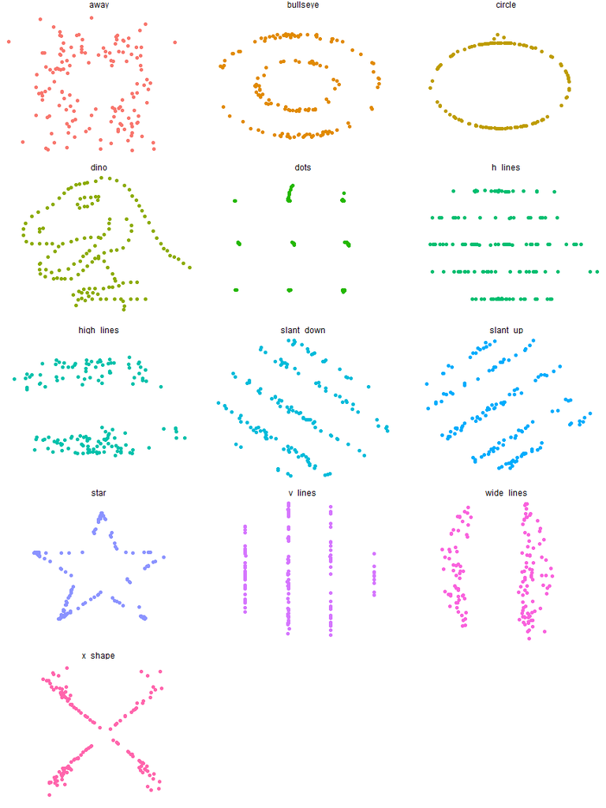

```r
  ggplot(datasaurus_dozen, aes(x = x, y = y, colour = dataset))+
    geom_point()+
    theme_void()+
    theme(legend.position = "none")+
    facet_wrap(~dataset, ncol = 3)
```

And did you notice the code in the {r} codechunk header that controlled the size of the output in the Rmd? Pretty neat trick!

And here are two versions of the data that you could use in your data visualization tutorial. To use them you would probably want to change the names of the datasets and also make x and y more meaningful. Then save them as a csv or tsv to be imported later for your tutorial.

```r
datasaurus_long <- datasaurus_dozen
datasaurus_wide <- datasaurus_dozen_wide
head(datasaurus_long)
```

| dataset | x | y |
| --- | --- | --- |
| dino | 55.3846 | 97.1795 |
| dino | 51.5385 | 96.0256 |
| dino | 46.1538 | 94.4872 |
| dino | 42.8205 | 91.4103 |
| dino | 40.7692 | 88.3333 |
| dino | 38.7179 | 84.8718 |

```r
head(datasaurus_wide)
```

| away_x | away_y | bullseye_x | bullseye_y | circle_x | circle_y | dino_x | dino_y | dots_x | dots_y | h_lines_x | h_lines_y | high_lines_x | high_lines_y | slant_down_x | slant_down_y | slant_up_x | slant_up_y | star_x | star_y | v_lines_x | v_lines_y | wide_lines_x | wide_lines_y | x_shape_x | x_shape_y |
| --- | --- | --- | --- | --- | --- | --- | --- | --- | --- | --- | --- | --- | --- | --- | --- | --- | --- | --- | --- | --- | --- | --- | --- | --- | --- |
| 32.33111 | 61.41110 | 51.20389 | 83.33978 | 55.99303 | 79.27726 | 55.3846 | 97.1795 | 51.14792 | 90.86741 | 53.36657 | 90.20803 | 57.61323 | 83.90517 | 52.87202 | 97.34322 | 47.69520 | 95.24119 | 58.21361 | 91.88189 | 50.48151 | 93.22270 | 65.81554 | 95.58837 | 38.33776 | 92.47272 |
| 53.42146 | 26.18688 | 58.97447 | 85.49982 | 50.03225 | 79.01307 | 51.5385 | 96.0256 | 50.51713 | 89.10239 | 52.80198 | 90.08806 | 51.27439 | 82.81798 | 59.01414 | 93.57487 | 44.60998 | 93.07584 | 58.19605 | 92.21499 | 50.28241 | 97.60998 | 65.67227 | 91.93340 | 35.75187 | 94.11677 |
| 63.92020 | 30.83219 | 51.87207 | 85.82974 | 51.28846 | 82.43594 | 46.1538 | 94.4872 | 50.20748 | 85.46005 | 47.05413 | 90.45894 | 50.75390 | 76.75413 | 56.37511 | 96.30515 | 43.85638 | 94.08587 | 58.71823 | 90.31053 | 50.18670 | 99.69468 | 39.00272 | 92.26184 | 32.76722 | 88.51829 |
| 70.28951 | 82.53365 | 48.17993 | 85.04512 | 51.17054 | 79.16529 | 42.8205 | 91.4103 | 50.06948 | 83.05767 | 42.44843 | 89.50770 | 37.02118 | 81.95447 | 37.83920 | 94.35944 | 41.57893 | 90.30357 | 57.27837 | 89.90761 | 50.32691 | 90.02205 | 37.79530 | 93.53246 | 33.72961 | 88.62227 |
| 34.11883 | 45.73455 | 41.68320 | 84.01794 | 44.37791 | 78.16463 | 40.7692 | 88.3333 | 50.56285 | 82.93782 | 42.70404 | 90.44263 | 42.88176 | 80.18477 | 39.88537 | 90.63466 | 49.17742 | 96.61053 | 58.08202 | 92.00815 | 50.45621 | 89.98741 | 35.51390 | 89.59919 | 37.23825 | 83.72493 |
| 67.67072 | 37.11095 | 37.89042 | 82.56749 | 45.01027 | 77.88086 | 38.7179 | 84.8718 | 50.28853 | 82.97525 | 32.37894 | 90.14414 | 37.15571 | 84.95411 | 44.07741 | 84.12585 | 42.65225 | 90.56064 | 57.48945 | 88.08529 | 30.46485 | 82.08923 | 39.21945 | 83.54348 | 36.02720 | 82.04078 |

# Acknowledgements

DatasauRus package and description below: Stephanie Locke https://github.com/jumpingrivers/datasauRus

The datasauRus package wraps the awesome Datasaurus Dozen dataset, which contains 13 sets of x-y data. Each sub-dataset has five statistics that are (almost) the same in each case. (These are the mean of x, mean of y, standard deviation of x, standard deviation of y, and Pearson correlation between x and y). However, scatter plots reveal that each sub-dataset looks very different. The dataset is intended to be used to teach students that it is important to plot their own datasets, rather than relying only on statistics.

The Datasaurus was created by Alberto Cairo in this great [blog post](http://www.thefunctionalart.com/2016/08/download-datasaurus-never-trust-summary.html).

He’s been subsequently made even more famous in the paper [Same Stats, Different Graphs: Generating Datasets with Varied Appearance and Identical Statistics through Simulated Annealing](https://www.autodeskresearch.com/publications/samestats) by Justin Matejka and George Fitzmaurice.

In the paper, Justin and George simulate a variety of datasets that the same summary statistics to the Datasaurus but have very different distributions.

This package also makes these datasets available for use as an advanced [Anscombe’s Quartet](https://en.wikipedia.org/wiki/Anscombe%27s_quartet), available in R as `anscombe`.